# Statistical Inference - final project

Wiktoria Urantowka

8/11/2017

The goal of this project is the applications of Central Limit THeorem to exponential distribution in R. The last one is simulated in R using command rexp(n, lambda) where lambda is the rate parameter. The mean of exponential distribution is the same as it’s standard deviation and amounts 1/lambda.

## A. Simulations

1. setting constants

```r
lambda <- 0.2 # lambda
n <- 40 # size of the sample
sim_num <- 1000 # number of drows
```

2. Setting seed for reproducibility

```r
set.seed(67893)
```

3. Simulating values from exponential distribution

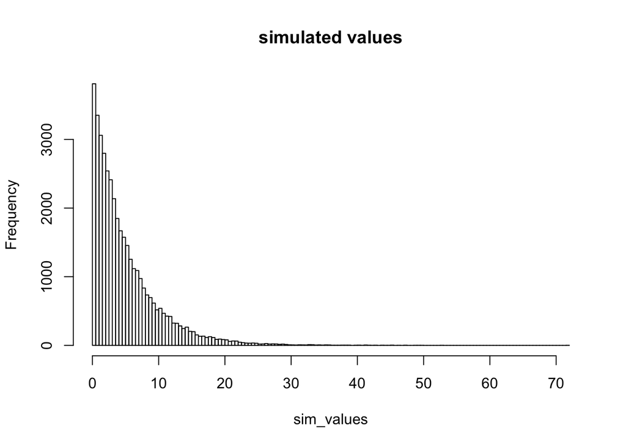

```r
sim_values<- rexp(n = sim_num * n,lambda)
hist(sim_values, main = "simulated values", breaks =200)
```

4. Create a dataframe with means of 1000 simulation of size n=40

```r
matrix <- matrix(rexp(n = sim_num * n,lambda), sim_num, n)
means <- rowMeans(matrix)
simData <- data.frame(cbind(matrix,means))
```

## B. Comparaison of theoretical and sample means of the distribution.

1. Theoretical mean of exponential distribution = 1/lambda

```r
theoretical_mean <- 1/lambda
theoretical_mean
```

```
## [1] 5
```

2. Mean from one drow of n=40 is given by:

```r
sample_mean <-mean(rexp(40, 0.2))
sample_mean
```

```
## [1] 3.995102
```

```r
mean_difference<-abs(theoretical_mean-sample_mean)
mean_difference
```

```
## [1] 1.004898
```

3. However, when we repeat it 1000 times and compute mean,

```r
mns = NULL
for (i in 1 : 1000) mns = c(mns, mean(rexp(40, 0.2)))
sample_mean1000<- mean(mns)
mean_difference2<-theoretical_mean-sample_mean1000
sample_mean1000
```

```
## [1] 4.954971
```

```r
mean_difference2
```

```
## [1] 0.04502878
```

One can see, that the difference between sample mean and theoretical mean shrinks further

4. Plotting the results and finding their mean value

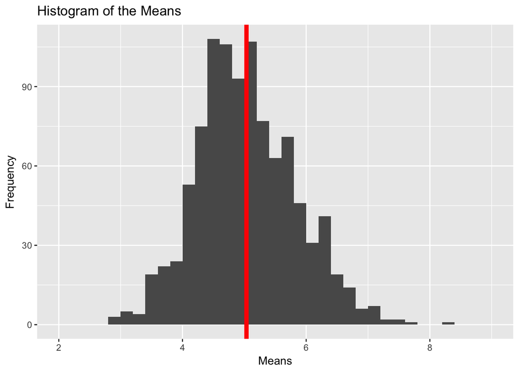

```r
library("ggplot2")
ggplot(data = simData, aes(simData$means)) +
  geom_histogram(breaks = seq(2, 9, by = 0.2)) +
  labs(title = "Histogram of the Means", x = "Means", y = "Frequency") +
  geom_vline(aes(xintercept=mean(simData$means)), color="red",
 size=2)
```

The histogram proves that the distribution of the means is centered around the mean of the simulated distribution, very very close to the theoretical mean = 5

## 2. Comparaison of theoretical and sample variance of the distribution.

1. Theoretical variance of exponential distribution is given by:

```r
theoretical_variance = ((1 / lambda) ^ 2) / n
theoretical_variance
```

```
## [1] 0.625
```

2. sample variance is given by

```r
sample_variance<-var(means)
sample_variance
```

```
## [1] 0.6412434
```

```r
var_difference <- theoretical_variance-sample_variance
var_difference
```

```
## [1] -0.01624341
```

One can see, that the variance difference between the theoretical and sample variance is very small

## Show that the distribution is approximately normal.

Showing that the simulated mean sample data approximately follows the Normal distribution when n is big (Central Limit Theorem) can be illustrated below: (Comparison of the plotted sample data with the plot of normal distribution)

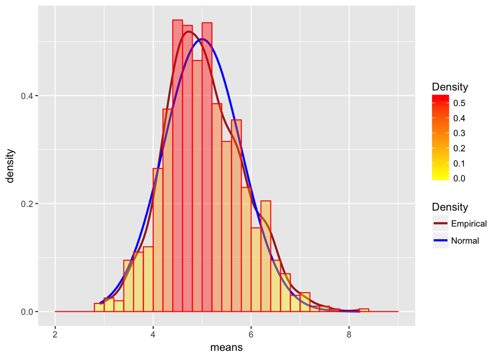

```r
qplot(means, geom = 'blank') +
  geom_line(aes(y=..density.., colour='Empirical'), stat='density', size=1) +
  stat_function(fun=dnorm, args=list(mean=(1/lambda), sd=((1/lambda)/sqrt(n))),
                aes(colour='Normal'), size=1) +
  geom_histogram(aes(y=..density.., fill=..density..), alpha=0.4,
                 breaks = seq(2, 9, by = 0.2), col='red') +
  scale_fill_gradient("Density", low = "yellow", high = "red") +
  scale_color_manual(name='Density', values=c('brown', 'blue'))
```

Comparying the “Empirical” (derived from exponential distribution) and “Normal” distributions clearly illustrates, that the sample data can be approximated with the normal distribution.

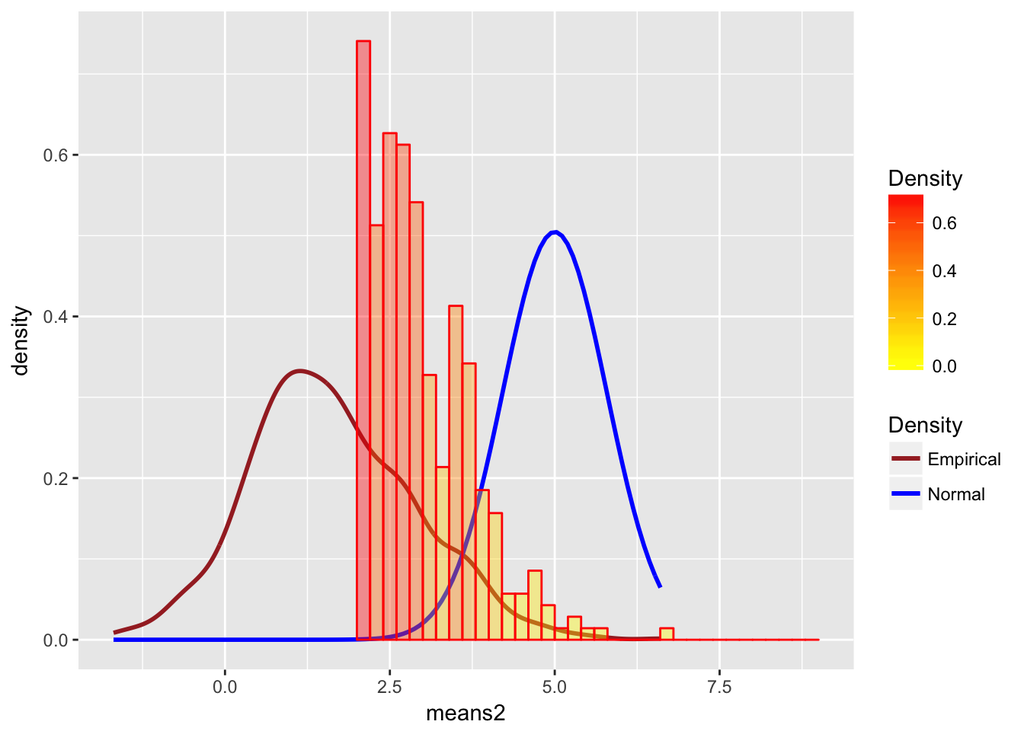

```r
means2 <- (means-sample_mean)/sample_variance
qplot(means2, geom = 'blank') +
  geom_line(aes(y=..density.., colour='Empirical'), stat='density', size=1) +
  stat_function(fun=dnorm, args=list(mean=(1/lambda), sd=((1/lambda)/sqrt(n))),
                aes(colour='Normal'), size=1) +
  geom_histogram(aes(y=..density.., fill=..density..), alpha=0.4,
                 breaks = seq(2, 9, by = 0.2), col='red') +
  scale_fill_gradient("Density", low = "yellow", high = "red") +
  scale_color_manual(name='Density', values=c('brown', 'blue'))
```